# Huynh_Truc_midterm

Truc

3/27/2020

## 1.Introduction

### 1.1 Summary:

The data is provided by Johns Hopkins CSSE (CSSEGISandData/COVID-19,n.d.) for the 2019 Novel Coronavirus Visual Dashboard. Also, Supported by ESRI Living Atlas Team and the Johns Hopkins University Applied Physics Lab (JHU APL).

### 1.2 Variables:

**Original data frame:**

- Province/State: Province, State of the following country.
- Country/Region: Country name.
- Lat: Latitude of the area.
- Long: Longtitude of the area.
- Other column names contain the date of records, column variable contain the number of record by day.

**Tidy data frame:**

- date: The date of each record.
- Other column contain the number of people of each country’s record.
- active: the number of active patient (non death nor recover )
- recover %: The percentage of recovery patient
- mortality %: The percentage of death patient
- active %: The percentage of COVID patient that active

## 2.COVID Worldwide

### 2.1 Worldwide COVID-19 Trend

Plot show country around the world affected by COVID since January through March.

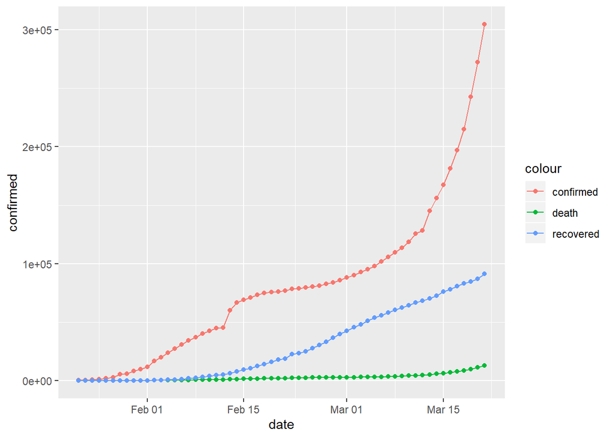

Conclusion: while the confirmed case keep increased, the change that the infected person will death is still very low.

### 2.2 Cases worldwide by date:

| date | confirmed | death | recovered | active | recovery.percent | mortality.percent |
| --- | --- | --- | --- | --- | --- | --- |
| 2020-01-22 | 555 | 17 | 28 | 510 | 5.045 | 3.063 |
| 2020-01-23 | 653 | 18 | 30 | 605 | 4.594 | 2.757 |
| 2020-01-24 | 941 | 26 | 36 | 879 | 3.826 | 2.763 |
| 2020-01-25 | 1434 | 42 | 39 | 1353 | 2.720 | 2.929 |
| 2020-01-26 | 2118 | 56 | 52 | 2010 | 2.455 | 2.644 |
| 2020-01-27 | 2927 | 82 | 61 | 2784 | 2.084 | 2.802 |
| 2020-01-28 | 5578 | 131 | 107 | 5340 | 1.918 | 2.349 |
| 2020-01-29 | 6166 | 133 | 126 | 5907 | 2.043 | 2.157 |
| 2020-01-30 | 8234 | 171 | 143 | 7920 | 1.737 | 2.077 |
| 2020-01-31 | 9927 | 213 | 222 | 9492 | 2.236 | 2.146 |
| 2020-02-01 | 12038 | 259 | 284 | 11495 | 2.359 | 2.152 |
| 2020-02-02 | 16787 | 362 | 472 | 15953 | 2.812 | 2.156 |
| 2020-02-03 | 19881 | 426 | 623 | 18832 | 3.134 | 2.143 |
| 2020-02-04 | 23892 | 492 | 852 | 22548 | 3.566 | 2.059 |
| 2020-02-05 | 27635 | 564 | 1124 | 25947 | 4.067 | 2.041 |
| 2020-02-06 | 30817 | 634 | 1487 | 28696 | 4.825 | 2.057 |
| 2020-02-07 | 34391 | 719 | 2011 | 31661 | 5.847 | 2.091 |
| 2020-02-08 | 37120 | 806 | 2616 | 33698 | 7.047 | 2.171 |
| 2020-02-09 | 40150 | 906 | 3244 | 36000 | 8.080 | 2.257 |
| 2020-02-10 | 42762 | 1013 | 3946 | 37803 | 9.228 | 2.369 |
| 2020-02-11 | 44802 | 1113 | 4683 | 39006 | 10.453 | 2.484 |
| 2020-02-12 | 45221 | 1118 | 5150 | 38953 | 11.389 | 2.472 |
| 2020-02-13 | 60368 | 1371 | 6295 | 52702 | 10.428 | 2.271 |
| 2020-02-14 | 66885 | 1523 | 8058 | 57304 | 12.048 | 2.277 |
| 2020-02-15 | 69030 | 1666 | 9395 | 57969 | 13.610 | 2.413 |
| 2020-02-16 | 71224 | 1770 | 10865 | 58589 | 15.255 | 2.485 |
| 2020-02-17 | 73258 | 1868 | 12583 | 58807 | 17.176 | 2.550 |
| 2020-02-18 | 75136 | 2007 | 14352 | 58777 | 19.101 | 2.671 |
| 2020-02-19 | 75639 | 2122 | 16121 | 57396 | 21.313 | 2.805 |
| 2020-02-20 | 76197 | 2247 | 18177 | 55773 | 23.855 | 2.949 |
| 2020-02-21 | 76823 | 2251 | 18890 | 55682 | 24.589 | 2.930 |
| 2020-02-22 | 78579 | 2458 | 22886 | 53235 | 29.125 | 3.128 |
| 2020-02-23 | 78965 | 2469 | 23394 | 53102 | 29.626 | 3.127 |
| 2020-02-24 | 79568 | 2629 | 25227 | 51712 | 31.705 | 3.304 |
| 2020-02-25 | 80413 | 2708 | 27905 | 49800 | 34.702 | 3.368 |
| 2020-02-26 | 81395 | 2770 | 30384 | 48241 | 37.329 | 3.403 |
| 2020-02-27 | 82754 | 2814 | 33277 | 46663 | 40.212 | 3.400 |
| 2020-02-28 | 84120 | 2872 | 36711 | 44537 | 43.641 | 3.414 |
| 2020-02-29 | 86011 | 2941 | 39782 | 43288 | 46.252 | 3.419 |
| 2020-03-01 | 88369 | 2996 | 42716 | 42657 | 48.338 | 3.390 |
| 2020-03-02 | 90306 | 3085 | 45602 | 41619 | 50.497 | 3.416 |
| 2020-03-03 | 92840 | 3160 | 48228 | 41452 | 51.947 | 3.404 |
| 2020-03-04 | 95120 | 3254 | 51170 | 40696 | 53.795 | 3.421 |
| 2020-03-05 | 97882 | 3348 | 53796 | 40738 | 54.960 | 3.420 |
| 2020-03-06 | 101784 | 3460 | 55865 | 42459 | 54.886 | 3.399 |
| 2020-03-07 | 105821 | 3558 | 58358 | 43905 | 55.148 | 3.362 |
| 2020-03-08 | 109795 | 3802 | 60694 | 45299 | 55.279 | 3.463 |
| 2020-03-09 | 113561 | 3988 | 62494 | 47079 | 55.031 | 3.512 |
| 2020-03-10 | 118592 | 4262 | 64404 | 49926 | 54.307 | 3.594 |
| 2020-03-11 | 125865 | 4615 | 67003 | 54247 | 53.234 | 3.667 |
| 2020-03-12 | 128343 | 4720 | 68324 | 55299 | 53.235 | 3.678 |
| 2020-03-13 | 145193 | 5404 | 70251 | 69538 | 48.385 | 3.722 |
| 2020-03-14 | 156094 | 5819 | 72624 | 77651 | 46.526 | 3.728 |
| 2020-03-15 | 167446 | 6440 | 76034 | 84972 | 45.408 | 3.846 |
| 2020-03-16 | 181527 | 7126 | 78088 | 96313 | 43.017 | 3.926 |
| 2020-03-17 | 197142 | 7905 | 80840 | 108397 | 41.006 | 4.010 |
| 2020-03-18 | 214910 | 8733 | 83207 | 122970 | 38.717 | 4.064 |
| 2020-03-19 | 242708 | 9867 | 84854 | 147987 | 34.961 | 4.065 |
| 2020-03-20 | 272166 | 11299 | 87256 | 173611 | 32.060 | 4.152 |
| 2020-03-21 | 304524 | 12973 | 91499 | 200052 | 30.047 | 4.260 |

### 2.3 Cases worldwide by country:

Show infected country order by infected case

| country | confirmed | death | recovered | active | recovery.percent | mortality.percent |
| --- | --- | --- | --- | --- | --- | --- |
| china | 3368333 | 112873 | 1642036 | 1613424 | 48.749 | 3.351 |
| italy | 379683 | 28483 | 36906 | 314294 | 9.720 | 7.502 |
| iran | 209494 | 11439 | 64067 | 133988 | 30.582 | 5.460 |
| korea_south | 163905 | 1335 | 12063 | 150507 | 7.360 | 0.814 |
| spain | 128664 | 5573 | 9218 | 113873 | 7.164 | 4.331 |
| germany | 111228 | 301 | 1296 | 109631 | 1.165 | 0.271 |
| us | 92491 | 1442 | 249 | 90800 | 0.269 | 1.559 |
| france | 86289 | 2185 | 354 | 83750 | 0.410 | 2.532 |
| switzerland | 31923 | 295 | 111 | 31517 | 0.348 | 0.924 |
| cruise_ship | 24804 | 173 | 3869 | 20762 | 15.598 | 0.697 |
| united_kingdom | 23883 | 818 | 674 | 22391 | 2.822 | 3.425 |
| netherlands | 19671 | 510 | 16 | 19145 | 0.081 | 2.593 |
| norway | 16009 | 39 | 13 | 15957 | 0.081 | 0.244 |
| japan | 15478 | 372 | 2511 | 12595 | 16.223 | 2.403 |
| belgium | 14522 | 171 | 356 | 13995 | 2.451 | 1.178 |
| austria | 14471 | 34 | 75 | 14362 | 0.518 | 0.235 |
| sweden | 13610 | 78 | 58 | 13474 | 0.426 | 0.573 |
| denmark | 11114 | 42 | 16 | 11056 | 0.144 | 0.378 |
| malaysia | 7585 | 13 | 1034 | 6538 | 13.632 | 0.171 |
| canada | 6159 | 64 | 208 | 5887 | 3.377 | 1.039 |
| singapore | 6105 | 2 | 2694 | 3409 | 44.128 | 0.033 |
| australia | 6067 | 69 | 627 | 5371 | 10.335 | 1.137 |
| portugal | 5107 | 24 | 27 | 5056 | 0.529 | 0.470 |
| czechia | 4619 | 0 | 22 | 4597 | 0.476 | 0.000 |
| israel | 4508 | 1 | 127 | 4380 | 2.817 | 0.022 |
| qatar | 4426 | 0 | 61 | 4365 | 1.378 | 0.000 |
| brazil | 4003 | 36 | 11 | 3956 | 0.275 | 0.899 |
| greece | 3925 | 49 | 86 | 3790 | 2.191 | 1.248 |
| thailand | 3436 | 21 | 1143 | 2272 | 33.265 | 0.611 |
| bahrain | 3423 | 6 | 837 | 2580 | 24.452 | 0.175 |

[output cut: 136 more lines]

The mortality percent seem lower than the recovery percent in most country. Especially country has the older population.

### 2.4 Cases worldwide’s trend (exclude China):

Plot to see infected case around the world that exclude China.

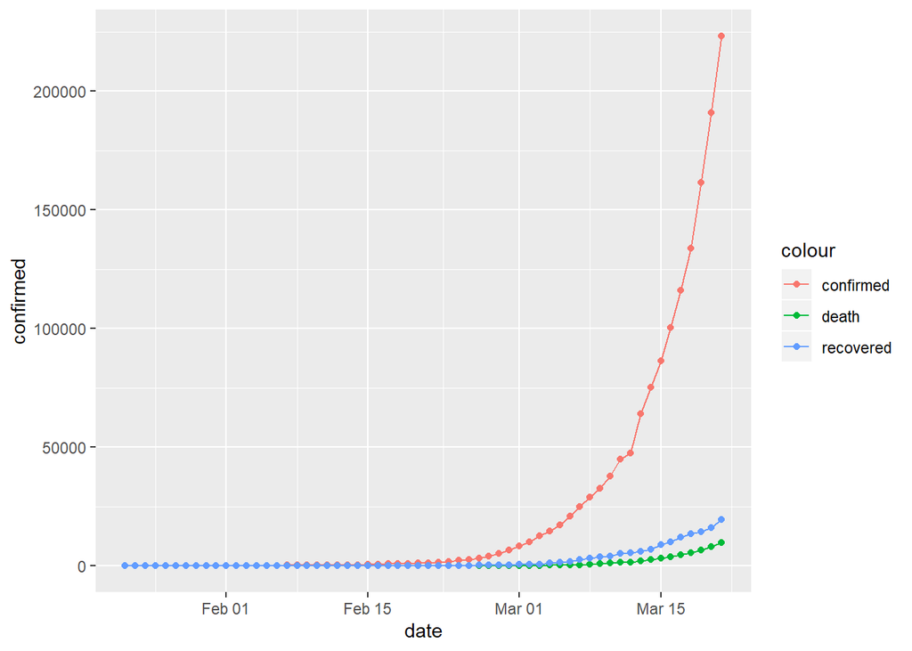

While take out China, the confirmed case is drop dramatically. However the recovered case also drop. Which being said, China has the most infected people, but they are doing pretty good to recover.

### 2.5 Cases worldwide’s total cases exclude China:

| date | confirmed | death | recovered | active | recovery.percent | mortality.percent |
| --- | --- | --- | --- | --- | --- | --- |
| 2020-01-22 | 7 | 0 | 0 | 7 | 0.000 | 0.000 |
| 2020-01-23 | 10 | 0 | 0 | 10 | 0.000 | 0.000 |
| 2020-01-24 | 21 | 0 | 0 | 21 | 0.000 | 0.000 |
| 2020-01-25 | 28 | 0 | 0 | 28 | 0.000 | 0.000 |
| 2020-01-26 | 43 | 0 | 3 | 40 | 6.977 | 0.000 |
| 2020-01-27 | 50 | 0 | 3 | 47 | 6.000 | 0.000 |
| 2020-01-28 | 69 | 0 | 6 | 63 | 8.696 | 0.000 |
| 2020-01-29 | 79 | 0 | 6 | 73 | 7.595 | 0.000 |
| 2020-01-30 | 93 | 0 | 8 | 85 | 8.602 | 0.000 |
| 2020-01-31 | 125 | 0 | 8 | 117 | 6.400 | 0.000 |
| 2020-02-01 | 147 | 0 | 9 | 138 | 6.122 | 0.000 |
| 2020-02-02 | 157 | 1 | 9 | 147 | 5.732 | 0.637 |
| 2020-02-03 | 165 | 1 | 9 | 155 | 5.455 | 0.606 |
| 2020-02-04 | 185 | 1 | 9 | 175 | 4.865 | 0.541 |
| 2020-02-05 | 195 | 1 | 9 | 185 | 4.615 | 0.513 |
| 2020-02-06 | 230 | 1 | 10 | 219 | 4.348 | 0.435 |
| 2020-02-07 | 281 | 1 | 12 | 268 | 4.270 | 0.356 |
| 2020-02-08 | 306 | 1 | 20 | 285 | 6.536 | 0.327 |
| 2020-02-09 | 321 | 1 | 25 | 295 | 7.788 | 0.312 |
| 2020-02-10 | 408 | 1 | 28 | 379 | 6.863 | 0.245 |
| 2020-02-11 | 416 | 1 | 47 | 368 | 11.298 | 0.240 |
| 2020-02-12 | 462 | 1 | 68 | 393 | 14.719 | 0.216 |
| 2020-02-13 | 473 | 2 | 78 | 393 | 16.490 | 0.423 |
| 2020-02-14 | 527 | 2 | 81 | 444 | 15.370 | 0.380 |
| 2020-02-15 | 617 | 3 | 97 | 517 | 15.721 | 0.486 |
| 2020-02-16 | 711 | 4 | 110 | 597 | 15.471 | 0.563 |
| 2020-02-17 | 824 | 4 | 121 | 699 | 14.684 | 0.485 |
| 2020-02-18 | 925 | 4 | 146 | 775 | 15.784 | 0.432 |
| 2020-02-19 | 1020 | 6 | 159 | 855 | 15.588 | 0.588 |
| 2020-02-20 | 1120 | 9 | 163 | 948 | 14.554 | 0.804 |
| 2020-02-21 | 1273 | 13 | 186 | 1074 | 14.611 | 1.021 |
| 2020-02-22 | 1578 | 15 | 187 | 1376 | 11.850 | 0.951 |
| 2020-02-23 | 1943 | 24 | 207 | 1712 | 10.654 | 1.235 |
| 2020-02-24 | 2327 | 34 | 212 | 2081 | 9.110 | 1.461 |
| 2020-02-25 | 2659 | 43 | 229 | 2387 | 8.612 | 1.617 |
| 2020-02-26 | 3229 | 53 | 300 | 2876 | 9.291 | 1.641 |
| 2020-02-27 | 4154 | 68 | 347 | 3739 | 8.353 | 1.637 |
| 2020-02-28 | 5192 | 82 | 382 | 4728 | 7.357 | 1.579 |
| 2020-02-29 | 6655 | 104 | 462 | 6089 | 6.942 | 1.563 |
| 2020-03-01 | 8437 | 124 | 554 | 7759 | 6.566 | 1.470 |
| 2020-03-02 | 10170 | 171 | 748 | 9251 | 7.355 | 1.681 |
| 2020-03-03 | 12579 | 213 | 778 | 11588 | 6.185 | 1.693 |
| 2020-03-04 | 14734 | 271 | 1169 | 13294 | 7.934 | 1.839 |
| 2020-03-05 | 17345 | 333 | 1504 | 15508 | 8.671 | 1.920 |
| 2020-03-06 | 21094 | 416 | 1921 | 18757 | 9.107 | 1.972 |
| 2020-03-07 | 25051 | 486 | 2819 | 21746 | 11.253 | 1.940 |
| 2020-03-08 | 28972 | 702 | 3306 | 24964 | 11.411 | 2.423 |
| 2020-03-09 | 32701 | 865 | 3690 | 28146 | 11.284 | 2.645 |
| 2020-03-10 | 37705 | 1123 | 4223 | 32359 | 11.200 | 2.978 |
| 2020-03-11 | 44944 | 1454 | 5359 | 38131 | 11.924 | 3.235 |
| 2020-03-12 | 47411 | 1548 | 5423 | 40440 | 11.438 | 3.265 |
| 2020-03-13 | 64248 | 2224 | 6055 | 55969 | 9.424 | 3.462 |
| 2020-03-14 | 75117 | 2626 | 6964 | 65527 | 9.271 | 3.496 |
| 2020-03-15 | 86443 | 3237 | 9017 | 74189 | 10.431 | 3.745 |
| 2020-03-16 | 100494 | 3909 | 10178 | 86407 | 10.128 | 3.890 |
| 2020-03-17 | 116084 | 4675 | 12042 | 99367 | 10.374 | 4.027 |
| 2020-03-18 | 133808 | 5492 | 13452 | 114864 | 10.053 | 4.104 |
| 2020-03-19 | 161552 | 6618 | 14319 | 140615 | 8.863 | 4.097 |
| 2020-03-20 | 190916 | 8046 | 15990 | 166880 | 8.375 | 4.214 |
| 2020-03-21 | 223219 | 9714 | 19642 | 193863 | 8.799 | 4.352 |

## 3.U.S. Analysis

### 3.1 Trend in the US

US plot with confired, death, and recovered

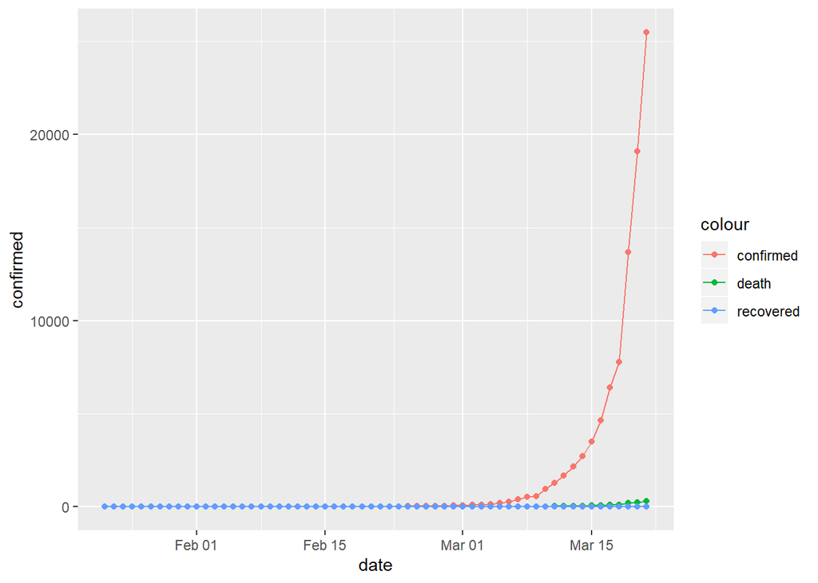

Conclusion: while the death case in the us is low, the recover in the us is lower compare to world wide. The infected case is rising faster than most contry

### 3.2 Trend in the US by date

US record of confired, death, and recovered due to COVID-19 by date

| date | confirmed | death | recovered | active | recovery.percent | mortality.percent |
| --- | --- | --- | --- | --- | --- | --- |
| 2020-01-22 | 1 | 0 | 0 | 1 | 0.000 | 0.000 |
| 2020-01-23 | 1 | 0 | 0 | 1 | 0.000 | 0.000 |
| 2020-01-24 | 2 | 0 | 0 | 2 | 0.000 | 0.000 |
| 2020-01-25 | 2 | 0 | 0 | 2 | 0.000 | 0.000 |
| 2020-01-26 | 5 | 0 | 0 | 5 | 0.000 | 0.000 |
| 2020-01-27 | 5 | 0 | 0 | 5 | 0.000 | 0.000 |
| 2020-01-28 | 5 | 0 | 0 | 5 | 0.000 | 0.000 |
| 2020-01-29 | 5 | 0 | 0 | 5 | 0.000 | 0.000 |
| 2020-01-30 | 5 | 0 | 0 | 5 | 0.000 | 0.000 |
| 2020-01-31 | 7 | 0 | 0 | 7 | 0.000 | 0.000 |
| 2020-02-01 | 8 | 0 | 0 | 8 | 0.000 | 0.000 |
| 2020-02-02 | 8 | 0 | 0 | 8 | 0.000 | 0.000 |
| 2020-02-03 | 11 | 0 | 0 | 11 | 0.000 | 0.000 |
| 2020-02-04 | 11 | 0 | 0 | 11 | 0.000 | 0.000 |
| 2020-02-05 | 11 | 0 | 0 | 11 | 0.000 | 0.000 |
| 2020-02-06 | 11 | 0 | 0 | 11 | 0.000 | 0.000 |
| 2020-02-07 | 11 | 0 | 0 | 11 | 0.000 | 0.000 |
| 2020-02-08 | 11 | 0 | 0 | 11 | 0.000 | 0.000 |
| 2020-02-09 | 11 | 0 | 3 | 8 | 27.273 | 0.000 |
| 2020-02-10 | 11 | 0 | 3 | 8 | 27.273 | 0.000 |
| 2020-02-11 | 12 | 0 | 3 | 9 | 25.000 | 0.000 |
| 2020-02-12 | 12 | 0 | 3 | 9 | 25.000 | 0.000 |
| 2020-02-13 | 13 | 0 | 3 | 10 | 23.077 | 0.000 |
| 2020-02-14 | 13 | 0 | 3 | 10 | 23.077 | 0.000 |
| 2020-02-15 | 13 | 0 | 3 | 10 | 23.077 | 0.000 |
| 2020-02-16 | 13 | 0 | 3 | 10 | 23.077 | 0.000 |
| 2020-02-17 | 13 | 0 | 3 | 10 | 23.077 | 0.000 |
| 2020-02-18 | 13 | 0 | 3 | 10 | 23.077 | 0.000 |
| 2020-02-19 | 13 | 0 | 3 | 10 | 23.077 | 0.000 |
| 2020-02-20 | 13 | 0 | 3 | 10 | 23.077 | 0.000 |
| 2020-02-21 | 15 | 0 | 5 | 10 | 33.333 | 0.000 |
| 2020-02-22 | 15 | 0 | 5 | 10 | 33.333 | 0.000 |
| 2020-02-23 | 15 | 0 | 5 | 10 | 33.333 | 0.000 |
| 2020-02-24 | 51 | 0 | 5 | 46 | 9.804 | 0.000 |
| 2020-02-25 | 51 | 0 | 6 | 45 | 11.765 | 0.000 |
| 2020-02-26 | 57 | 0 | 6 | 51 | 10.526 | 0.000 |
| 2020-02-27 | 58 | 0 | 6 | 52 | 10.345 | 0.000 |
| 2020-02-28 | 60 | 0 | 7 | 53 | 11.667 | 0.000 |
| 2020-02-29 | 68 | 1 | 7 | 60 | 10.294 | 1.471 |
| 2020-03-01 | 74 | 1 | 7 | 66 | 9.459 | 1.351 |
| 2020-03-02 | 98 | 6 | 7 | 85 | 7.143 | 6.122 |
| 2020-03-03 | 118 | 7 | 7 | 104 | 5.932 | 5.932 |
| 2020-03-04 | 149 | 11 | 7 | 131 | 4.698 | 7.383 |
| 2020-03-05 | 217 | 12 | 7 | 198 | 3.226 | 5.530 |
| 2020-03-06 | 262 | 14 | 7 | 241 | 2.672 | 5.344 |
| 2020-03-07 | 402 | 17 | 7 | 378 | 1.741 | 4.229 |
| 2020-03-08 | 518 | 21 | 7 | 490 | 1.351 | 4.054 |
| 2020-03-09 | 583 | 22 | 7 | 554 | 1.201 | 3.774 |
| 2020-03-10 | 959 | 28 | 8 | 923 | 0.834 | 2.920 |
| 2020-03-11 | 1281 | 36 | 8 | 1237 | 0.625 | 2.810 |

Conclusion: while the death case in the us is low, the recover in the us is much lower compare to world wide. The infected case is rising fast in a very short time (due to weather condition)

### 3.3 Trend in the US by state

US table by state and province with confired, death, and recovered

| state.province | confirmed | death | recovered | active | recovery.percent | mortality.percent |
| --- | --- | --- | --- | --- | --- | --- |
| new_york | 32952 | 180 | 0 | 32772 | 0.000 | 0.546 |
| washington | 10545 | 606 | 8 | 9931 | 0.076 | 5.747 |
| california | 7089 | 121 | 40 | 6928 | 0.564 | 1.707 |
| new_jersey | 3934 | 51 | 2 | 3881 | 0.051 | 1.296 |
| florida | 2643 | 65 | 0 | 2578 | 0.000 | 2.459 |
| massachusetts | 2619 | 2 | 8 | 2609 | 0.305 | 0.076 |
| illinois | 2460 | 17 | 16 | 2427 | 0.650 | 0.691 |
| louisiana | 2334 | 54 | 0 | 2280 | 0.000 | 2.314 |
| georgia | 1958 | 46 | 0 | 1912 | 0.000 | 2.349 |
| michigan | 1953 | 11 | 0 | 1942 | 0.000 | 0.563 |
| colorado | 1909 | 19 | 0 | 1890 | 0.000 | 0.995 |
| texas | 1836 | 19 | 0 | 1817 | 0.000 | 1.035 |
| pennsylvania | 1450 | 4 | 0 | 1446 | 0.000 | 0.276 |
| diamond_princess | 1210 | 0 | 0 | 1210 | 0.000 | 0.000 |
| tennessee | 1094 | 1 | 0 | 1093 | 0.000 | 0.091 |
| wisconsin | 954 | 7 | 8 | 939 | 0.839 | 0.734 |
| ohio | 831 | 5 | 0 | 826 | 0.000 | 0.602 |
| north_carolina | 823 | 0 | 0 | 823 | 0.000 | 0.000 |
| connecticut | 780 | 9 | 0 | 771 | 0.000 | 1.154 |
| maryland | 740 | 4 | 6 | 730 | 0.811 | 0.541 |
| virginia | 719 | 13 | 0 | 706 | 0.000 | 1.808 |
| oregon | 645 | 16 | 0 | 629 | 0.000 | 2.481 |
| minnesota | 620 | 1 | 0 | 619 | 0.000 | 0.161 |
| nevada | 613 | 7 | 0 | 606 | 0.000 | 1.142 |
| south_carolina | 594 | 8 | 0 | 586 | 0.000 | 1.347 |
| utah | 492 | 0 | 0 | 492 | 0.000 | 0.000 |
| king_county_wa | 465 | 93 | 30 | 342 | 6.452 | 20.000 |
| indiana | 447 | 13 | 0 | 434 | 0.000 | 2.908 |
| alabama | 429 | 0 | 0 | 429 | 0.000 | 0.000 |
| arkansas | 398 | 0 | 0 | 398 | 0.000 | 0.000 |
| arizona | 364 | 1 | 8 | 355 | 2.198 | 0.275 |
| mississippi | 356 | 3 | 0 | 353 | 0.000 | 0.843 |
| district_of_columbia | 324 | 2 | 0 | 322 | 0.000 | 0.617 |
| iowa | 321 | 0 | 0 | 321 | 0.000 | 0.000 |
| grand_princess | 319 | 0 | 0 | 319 | 0.000 | 0.000 |
| kentucky | 317 | 10 | 2 | 305 | 0.631 | 3.155 |
| rhode_island | 308 | 0 | 0 | 308 | 0.000 | 0.000 |
| westchester_county_ny | 286 | 0 | 0 | 286 | 0.000 | 0.000 |
| maine | 285 | 0 | 0 | 285 | 0.000 | 0.000 |
| new_hampshire | 253 | 0 | 0 | 253 | 0.000 | 0.000 |

Conclusion: While NewYork has the most confirmed case, Washington state has the most death case. Most big state (New York, Washington, California, New Jersey, Illinois… ) in the US got more infected cases compared to other state

## World wide case and the recover change

### 4.1 World wide Plot

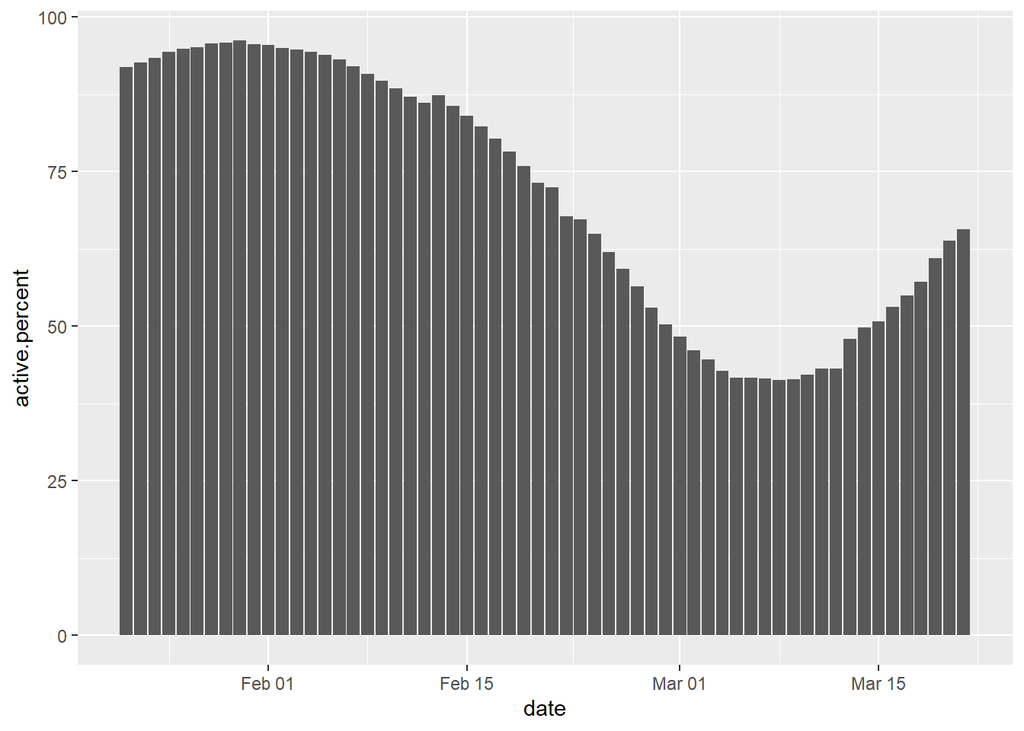

### 4.2 Worldwide Record with the active percentage

| date | confirmed | death | recovered | active | recovery.percent | mortality.percent | active.percent |
| --- | --- | --- | --- | --- | --- | --- | --- |
| 2020-01-22 | 555 | 17 | 28 | 510 | 5.045 | 3.063 | 91.892 |
| 2020-01-23 | 653 | 18 | 30 | 605 | 4.594 | 2.757 | 92.649 |
| 2020-01-24 | 941 | 26 | 36 | 879 | 3.826 | 2.763 | 93.411 |
| 2020-01-25 | 1434 | 42 | 39 | 1353 | 2.720 | 2.929 | 94.351 |
| 2020-01-26 | 2118 | 56 | 52 | 2010 | 2.455 | 2.644 | 94.901 |
| 2020-01-27 | 2927 | 82 | 61 | 2784 | 2.084 | 2.802 | 95.114 |
| 2020-01-28 | 5578 | 131 | 107 | 5340 | 1.918 | 2.349 | 95.733 |
| 2020-01-29 | 6166 | 133 | 126 | 5907 | 2.043 | 2.157 | 95.800 |
| 2020-01-30 | 8234 | 171 | 143 | 7920 | 1.737 | 2.077 | 96.187 |
| 2020-01-31 | 9927 | 213 | 222 | 9492 | 2.236 | 2.146 | 95.618 |
| 2020-02-01 | 12038 | 259 | 284 | 11495 | 2.359 | 2.152 | 95.489 |
| 2020-02-02 | 16787 | 362 | 472 | 15953 | 2.812 | 2.156 | 95.032 |
| 2020-02-03 | 19881 | 426 | 623 | 18832 | 3.134 | 2.143 | 94.724 |
| 2020-02-04 | 23892 | 492 | 852 | 22548 | 3.566 | 2.059 | 94.375 |
| 2020-02-05 | 27635 | 564 | 1124 | 25947 | 4.067 | 2.041 | 93.892 |
| 2020-02-06 | 30817 | 634 | 1487 | 28696 | 4.825 | 2.057 | 93.117 |
| 2020-02-07 | 34391 | 719 | 2011 | 31661 | 5.847 | 2.091 | 92.062 |
| 2020-02-08 | 37120 | 806 | 2616 | 33698 | 7.047 | 2.171 | 90.781 |
| 2020-02-09 | 40150 | 906 | 3244 | 36000 | 8.080 | 2.257 | 89.664 |
| 2020-02-10 | 42762 | 1013 | 3946 | 37803 | 9.228 | 2.369 | 88.403 |
| 2020-02-11 | 44802 | 1113 | 4683 | 39006 | 10.453 | 2.484 | 87.063 |
| 2020-02-12 | 45221 | 1118 | 5150 | 38953 | 11.389 | 2.472 | 86.139 |
| 2020-02-13 | 60368 | 1371 | 6295 | 52702 | 10.428 | 2.271 | 87.301 |
| 2020-02-14 | 66885 | 1523 | 8058 | 57304 | 12.048 | 2.277 | 85.675 |
| 2020-02-15 | 69030 | 1666 | 9395 | 57969 | 13.610 | 2.413 | 83.977 |
| 2020-02-16 | 71224 | 1770 | 10865 | 58589 | 15.255 | 2.485 | 82.260 |
| 2020-02-17 | 73258 | 1868 | 12583 | 58807 | 17.176 | 2.550 | 80.274 |
| 2020-02-18 | 75136 | 2007 | 14352 | 58777 | 19.101 | 2.671 | 78.227 |
| 2020-02-19 | 75639 | 2122 | 16121 | 57396 | 21.313 | 2.805 | 75.881 |
| 2020-02-20 | 76197 | 2247 | 18177 | 55773 | 23.855 | 2.949 | 73.196 |
| 2020-02-21 | 76823 | 2251 | 18890 | 55682 | 24.589 | 2.930 | 72.481 |
| 2020-02-22 | 78579 | 2458 | 22886 | 53235 | 29.125 | 3.128 | 67.747 |
| 2020-02-23 | 78965 | 2469 | 23394 | 53102 | 29.626 | 3.127 | 67.248 |
| 2020-02-24 | 79568 | 2629 | 25227 | 51712 | 31.705 | 3.304 | 64.991 |
| 2020-02-25 | 80413 | 2708 | 27905 | 49800 | 34.702 | 3.368 | 61.930 |
| 2020-02-26 | 81395 | 2770 | 30384 | 48241 | 37.329 | 3.403 | 59.268 |
| 2020-02-27 | 82754 | 2814 | 33277 | 46663 | 40.212 | 3.400 | 56.388 |
| 2020-02-28 | 84120 | 2872 | 36711 | 44537 | 43.641 | 3.414 | 52.945 |
| 2020-02-29 | 86011 | 2941 | 39782 | 43288 | 46.252 | 3.419 | 50.328 |
| 2020-03-01 | 88369 | 2996 | 42716 | 42657 | 48.338 | 3.390 | 48.271 |
| 2020-03-02 | 90306 | 3085 | 45602 | 41619 | 50.497 | 3.416 | 46.087 |
| 2020-03-03 | 92840 | 3160 | 48228 | 41452 | 51.947 | 3.404 | 44.649 |
| 2020-03-04 | 95120 | 3254 | 51170 | 40696 | 53.795 | 3.421 | 42.784 |
| 2020-03-05 | 97882 | 3348 | 53796 | 40738 | 54.960 | 3.420 | 41.620 |
| 2020-03-06 | 101784 | 3460 | 55865 | 42459 | 54.886 | 3.399 | 41.715 |
| 2020-03-07 | 105821 | 3558 | 58358 | 43905 | 55.148 | 3.362 | 41.490 |
| 2020-03-08 | 109795 | 3802 | 60694 | 45299 | 55.279 | 3.463 | 41.258 |
| 2020-03-09 | 113561 | 3988 | 62494 | 47079 | 55.031 | 3.512 | 41.457 |
| 2020-03-10 | 118592 | 4262 | 64404 | 49926 | 54.307 | 3.594 | 42.099 |
| 2020-03-11 | 125865 | 4615 | 67003 | 54247 | 53.234 | 3.667 | 43.099 |
| 2020-03-12 | 128343 | 4720 | 68324 | 55299 | 53.235 | 3.678 | 43.087 |
| 2020-03-13 | 145193 | 5404 | 70251 | 69538 | 48.385 | 3.722 | 47.893 |
| 2020-03-14 | 156094 | 5819 | 72624 | 77651 | 46.526 | 3.728 | 49.746 |
| 2020-03-15 | 167446 | 6440 | 76034 | 84972 | 45.408 | 3.846 | 50.746 |
| 2020-03-16 | 181527 | 7126 | 78088 | 96313 | 43.017 | 3.926 | 53.057 |
| 2020-03-17 | 197142 | 7905 | 80840 | 108397 | 41.006 | 4.010 | 54.984 |
| 2020-03-18 | 214910 | 8733 | 83207 | 122970 | 38.717 | 4.064 | 57.219 |
| 2020-03-19 | 242708 | 9867 | 84854 | 147987 | 34.961 | 4.065 | 60.973 |
| 2020-03-20 | 272166 | 11299 | 87256 | 173611 | 32.060 | 4.152 | 63.789 |
| 2020-03-21 | 304524 | 12973 | 91499 | 200052 | 30.047 | 4.260 | 65.693 |

## Conclusion

### 5.1 What I learn about COVID-19

COVID is a worldwide disaster and has kill many people. How ever we can prevent it by keep social distances and personal hygiene.

### 5.2 Data vs. Media

What I learn about COVID-19 is not exactly match the media said. COVID-19 is dangerous but we can still put it under control. (Refer to chart 4.2) At one point we are able to lower the spread wordwide (beginning of March)

### 5.3 Advise

COVID can spread pretty, and it can kill multiple people. These are advice that I learn from the US CDC:

- Regularly and thoroughly clean your hands with an alcohol-based hand rub or wash them with soap and water.
- Maintain at least 1 metre (3 feet) distance between yourself and anyone who is coughing or sneezing.
- Avoid touching eyes, nose and mouth
- Stay home if you feel unwell.